# MovieLens Project Report

Ryan Dobler - rydob2k

2023-10-31

## Objective

The goal of this project was to develop an algorithm for predicting movie ratings from a data set of user and movie information, similar to the Netflix Prize competition.

## 1. Introduction and Abstract

In 2006, Netflix hosted a competition where a prize of US$1 million was offered to contestants who could submit the best collaborative filtering algorithm for predicting user ratings for movies based on a data set of over 100 million ratings. The algorithms had to beat Netflix’s algorithm by 10%. Evaluation of the contestants models was done by comparing the root mean squared errors of the models.

Many companies such as Netflix and Amazon use User-Item collaborative filtering algorithms for recommending items to their customers. These recommendation systems use machine learning models to maximize their effectiveness. The motivation for this project was to create a model for predicting movie ratings from a previously available data set from the GroupLens group. This data set was a collection of user and movie ratings that had a timestamp for each rating. Also, each movie was associated with a title and a set of genres that could be used in analysis.

### *Abstract*

This project was executed in RStudio using the R programming language. In order to mimic the Netflix Prize challenge, a final holdout test set and a training data set were partitioned for model development. The root mean squared error (RMSE) was used to evaluate the effectiveness of the models. The 10M MovieLens data set was imported from GroupLens, then organized and cleaned for analysis. After exploratory analysis, several models were developed and ultimately a matrix factorization model was selected.

The final reportable RMSE was `0.8332669`.

## 2. Methods and Analysis

The overall strategy for this project was to import the data set, clean and wrangle the data for analysis, explore and visualize the data, develop an effective model for predicting ratings, and test the performance of the model on a hold-out data set.

### *Data Import*

Data were organized, prepared, and analyzed in Rstudio using the following packages:  
- `library(tidyverse)`  
- `library(caret)`  
- `library(qdaptools)`  
- `library(recosystem)`

The MovieLens 10M data set was made available through GroupLens, a research group that explores Information Filtering and Recommender Systems ([MovieLens 10M Summary](https://files.grouplens.org/datasets/movielens/ml-10m-README.html)). The data set was downloaded from the GroupLens website and imported to Rstudio for cleaning and reshaping.

After download, the MovieLens 10M file was unzipped into its component files: a `ratings.dat` file containing the user, movie, and timestamp for each rating, and a `movies.dat` file containing the movieId, title, and genres information. A third file `tags.dat` was not used for this project.

### *Cleaning and Wrangling*

The data were prepared for analysis using functions from `library(tidyverse)`. The `ratings.dat` and `movies.dat` files were organized into data frames and reshaped into tidy format, where each row is an observation and each column represents a variable, and the data are values in those respective ‘cells’ of the data frame. Tidy data are much more useful to work with when performing data exploration and analysis.

Several techniques were employed to clean and wrangle the data for exploration. Variables were defined using string processing and their values assigned with `str_split`. Variables were then renamed for interpretability.

Once the separate ratings and movies files were processed, they were combined to create a unified data set `movielens`.

In order to imitate the Netflix Prize challenge, the `movielens` data set was partitioned into a main training set and a final hold-out test set. The final hold-out data were reserved for testing the final model. From the main training set, another partition was made for training and testing algorithms.

```r
# Final hold-out test set is 10% of MovieLens data
set.seed(1, sample.kind="Rounding") # if using R 3.6 or later
test_index <- createDataPartition(y = movielens$rating, times = 1, p = 0.1, list = FALSE)
edx <- movielens[-test_index,]
temp <- movielens[test_index,]

# Make sure userId and movieId in final hold-out test set are also in edx set
final_holdout_test <- temp %>%
  semi_join(edx, by = "movieId") %>%
  semi_join(edx, by = "userId")

# Add rows removed from final hold-out test set back into edx set
removed <- anti_join(temp, final_holdout_test)
edx <- rbind(edx, removed)

# Remove non-relevant objects prior to analysis
rm(dl, ratings, movies, test_index, temp, movielens, removed)
```

```r
# Partition edx into training and test sets
set.seed(10)
edx_test_index <- createDataPartition(y = edx$rating, times = 1, p = 0.1, list = FALSE)
train_edx <- edx[-edx_test_index,]
temp2 <- edx[edx_test_index,]

# Make sure userId and movieId in test set are also in train set to avoid NAs
test_edx <- temp2 %>%
  semi_join(train_edx, by = "movieId") %>%
  semi_join(train_edx, by = "userId")

# Add rows removed from final hold-out test set back into edx set
removed <- anti_join(temp2, test_edx)
train_edx <- rbind(train_edx, removed)

# Clean up unused object from environment
rm(edx_test_index, temp2, removed)
```

### *Data Exploration*

```r
kable(head(edx, n=10))
```

[output not shown]

```r
str(edx)
```

[output not shown]

```r
n_users_movies <- edx %>% summarize(Users = n_distinct(userId),
                  Movies = n_distinct(movieId))
kable(n_users_movies)
```

| Users | Movies |
| --- | --- |
| 69878 | 10677 |

###### *USERS*

The average number of ratings per user was `129`, but the majority of users rated less than `62` movies. This suggests that the distribution of the number of ratings is skewed.

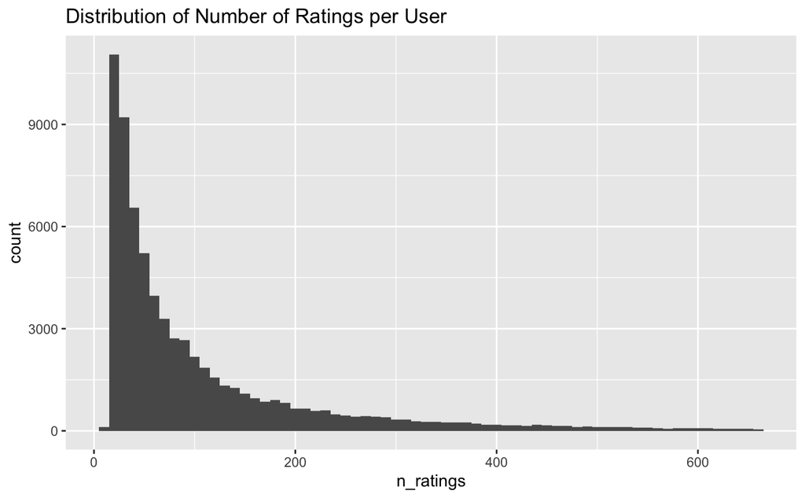

Additionally, there was a large variation in the average rating given by a user, as seen in the plot below. The average movie rating per user was `3.613711`, while the average rating was `3.5124652`. This `2.8824723` percent difference indicates some level of user bias impacting the rating.

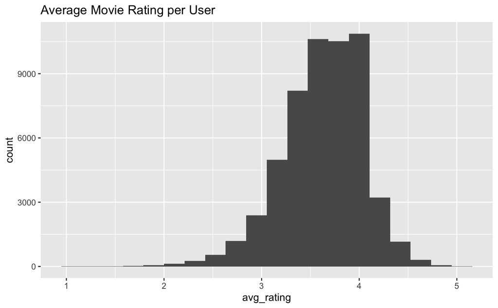